# Preliminary Data Analysis of White-Tailed Deer Data

# Spatial Data Maps

## Spatial Data Import

```r
NC_map <- st_read("/Users/huangyiping/KalsiGivensHuangYang/data/processed/NC_map_joined.shp")
```

## Map Plotting

### HU_dif Map

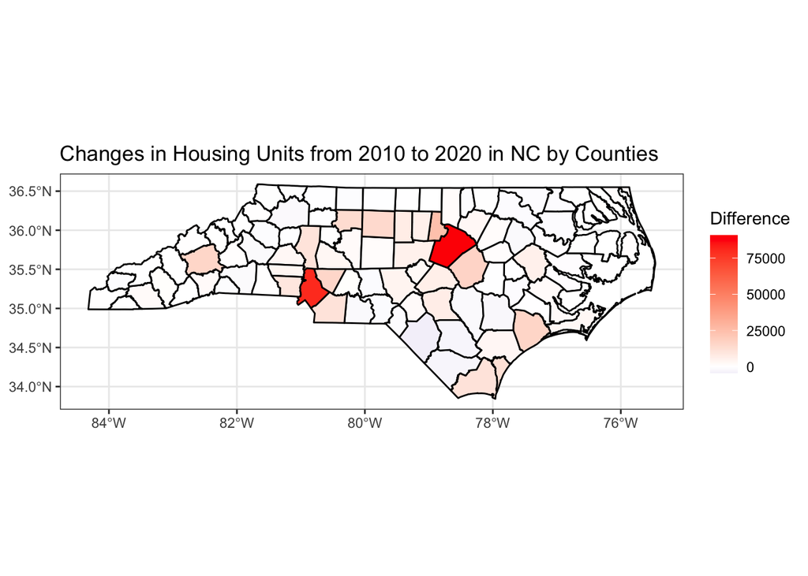

```r
map_HU_dif = ggplot(data=NC_map) +
  geom_sf(color = "black", linewidth = 0.5, aes(fill = HU_dif)) +
  scale_fill_gradient2(low="darkblue",high="red", midpoint = 0) +
  theme_bw() +
  labs(title = "Changes in Housing Units from 2010 to 2020 in NC by Counties",
       fill = "Difference")
map_HU_dif
```

### HUDEN_dif Map

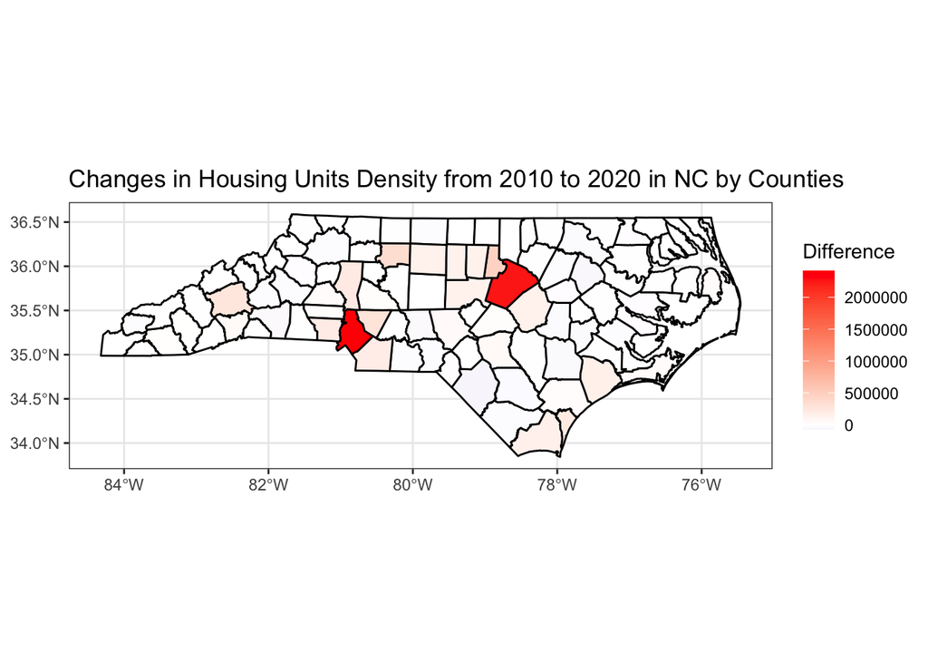

```r
map_HUDEN_dif = ggplot(data=NC_map) +
  geom_sf(color = "black", linewidth = 0.5, aes(fill = HUDEN_dif)) +
  scale_fill_gradient2(low="darkblue",high="red", midpoint = 0) +
  theme_bw() +
  labs(title = "Changes in Housing Units Density from 2010 to 2020 in NC by Counties",
       fill = "Difference")
map_HUDEN_dif
```

### VEG_dif Map

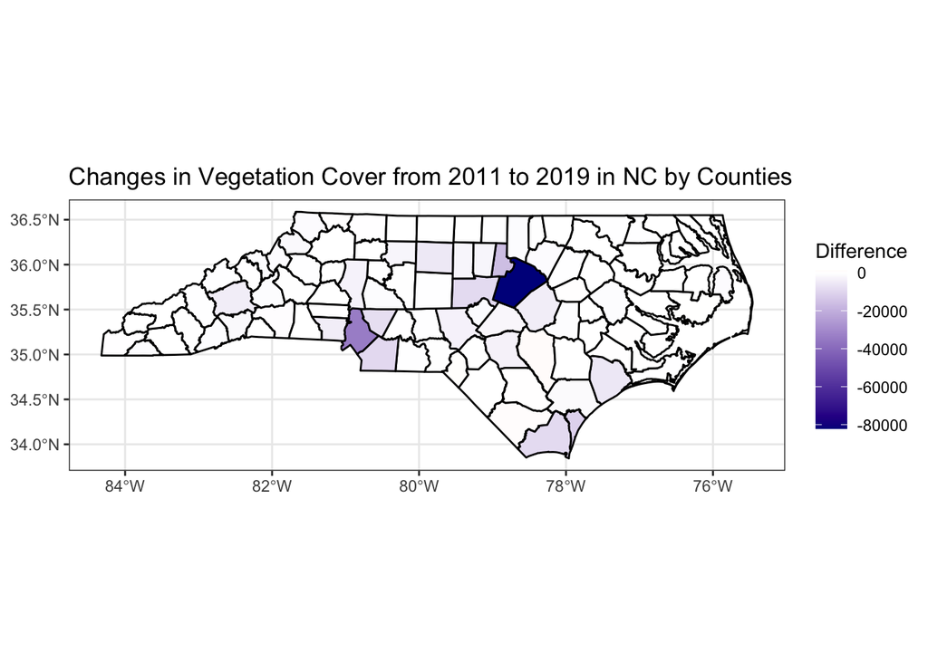

```r
map_VEG_dif = ggplot(data=NC_map) +
  geom_sf(color = "black", linewidth = 0.5, aes(fill = VEG_dif)) +
  scale_fill_gradient2(low="darkblue",high="red", midpoint = 0) +
  theme_bw() +
  labs(title = "Changes in Vegetation Cover from 2011 to 2019 in NC by Counties",
       fill = "Difference")
map_VEG_dif
```

## Interpretation

The three maps indicates that in counties that more housing units were build between 2010 to 2020, the housing unit density also increased, and the vegatation coverage decreased.

# Deer Map

## Data Import

```r
df_deer <- read_csv("/Users/huangyiping/KalsiGivensHuangYang/data/raw/NC_WhiteTailedDeer_iNaturalist_public.csv")
```

## Data Wrangling

```r
df_deer_spatial <- df_deer[
  !is.na(df_deer$observed_on) &
  df_deer$observed_on >= as.Date("2010-01-01") &
  df_deer$observed_on <= as.Date("2020-12-31"),] %>%
  mutate(year = as.integer(format(observed_on, "%Y"))) %>%
  select(observed_on, year, longitude, latitude) %>%
  mutate(year = as.character(year)) %>%
  st_as_sf(coords = c('longitude','latitude'), crs=4269)
```

## Mapping

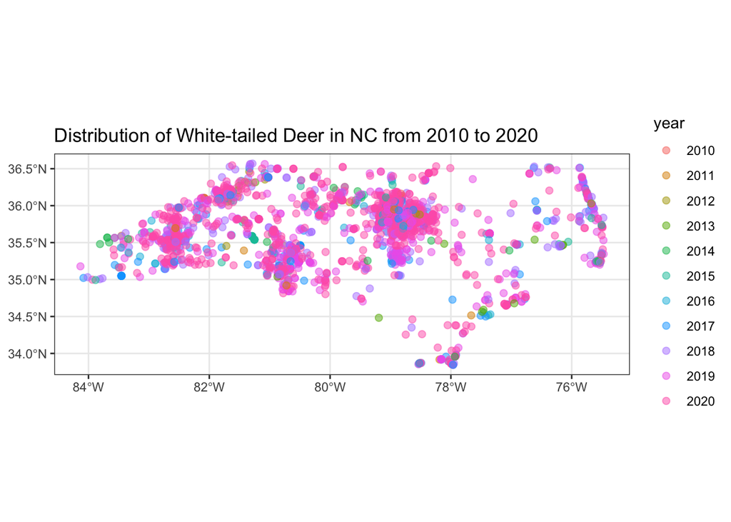

```r
map_deer = ggplot(data=df_deer_spatial, aes(color = year)) +
  geom_sf(size = 2, alpha=0.5) +
  theme_bw() +
  labs(title = "Distribution of White-tailed Deer in NC from 2010 to 2020")
map_deer
```

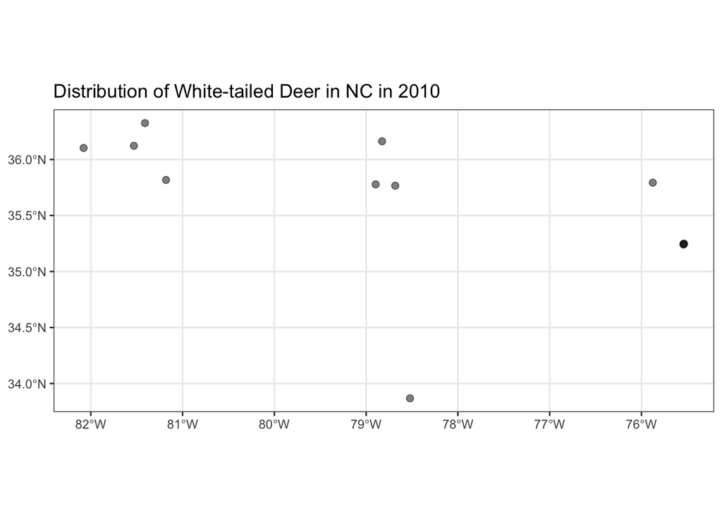

```r
map_deer_2010 = ggplot(data=df_deer_spatial%>%filter(year == "2010")) +
  geom_sf(size = 2, alpha=0.5) +
  theme_bw() +
  labs(title = "Distribution of White-tailed Deer in NC in 2010")
map_deer_2010
```

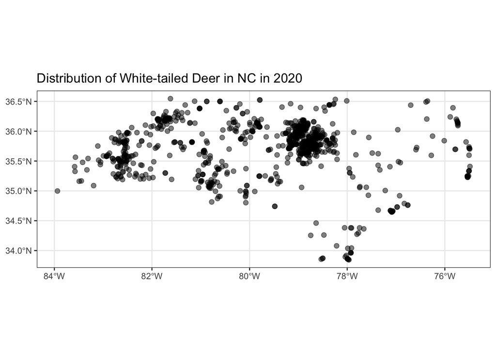

```r
map_deer_2020 = ggplot(data=df_deer_spatial%>%filter(year == "2020")) +
  geom_sf(size = 2, alpha=0.5) +
  theme_bw() +
  labs(title = "Distribution of White-tailed Deer in NC in 2020")
map_deer_2020
```

## Interpretation

The observation distribution of white-tailed deer from 2010 to 2020 is well-spread across NC. However, there are much fewer data points for observation in 2010, which we need to take into account while analyzing the deer distribution against human development.